# HW1 - An Evaluation of Sentiment Classification Tools

Background:

Artificial Intelligence (AI) has become a popular topic recently. Assume that you are a consultant at a public relations firm, and a client of your firm would like you to evaluate the current public sentiment toward AI in social media like Facebook and Twitter.

Since there are too many comments on social media, you can't manually collect and analyze them all. Fortunately you have discovered some free sentiment analysis tools, and now need to evaluate whether they are good enough to do sentiment analysis for your assigned task.

Goals:

1) You need to collect a sample data set and

2) choose two (2) tools to compare their effectiveness in sentiment analysis.

3) Write a report – USE MY REQUIRED FORMAT

- Include in the correct sections the following (and more)
  1. to describe (1) your sampling strategy - how did you get/create data?
  2. and whether it would result in a representative sample of public sentiment toward AI,
  3. (2) data preparation – how did you prepare your data for analysis – did you clean it? Did you format it? What are the variables? What do the variables represent? Is it labeled data?
  4. and system evaluation process – this means that you should explain the methods you chose and what you did with them. DO NOT INCLUDE CODE in your papers. All code is submitted as .py.
  5. and (3) your conclusion on whether these tools are suitable for your task. – here, because the required FORMAT has Results and Conclusions sections – read about what these mean and think about how to meet the requirements of each given the specifications of this assignment.
- A few examples of tools:
  1. NLTK’s built-in sentiment analysis tools. See sample code in http://www.nltk.org/howto/sentiment.html
  2. VADER https://github.com/cjhutto/vaderSentiment

### Import data

```python
import pandas as pd
import matplotlib.pyplot as plt
pd.set_option('display.max_colwidth', 1000)
pd.set_option('display.max_rows', 500)
pd.set_option('colheader_justify', 'center')
```

```python
#url='https://raw.githubusercontent.com/bing020815/Syracuse-University/master/IST%20736/HW1/data/tweets.csv'
url='https://raw.githubusercontent.com/bing020815/Syracuse-University/master/IST%20736/HW1/data/AI.csv'
tweets = pd.read_csv(url)
```

```python
AI = pd.read_csv('AI.csv')
```

```python
#tweets = pd.read_csv('tweets.csv', encoding='utf-8', quotechar='"')
```

```python
tweets['Tweets']=tweets.Tweets.map(str.strip)
tweets=tweets.set_index('Item')
```

```python
tweets.head()
```

| Item | Sentiment | Tweets |
| --- | --- | --- |
| 1 | 0 | in case anyone was wondering how quarantine is going, here’s a real thought i had today: “i’m not scared of artificial intelligence; i’m scared of my puns becoming sentient” |
| 2 | 0 | #ExMachina this movie blows my mind artificial intelligence can be exciting but at the same time detrimental when it comes to how powerful they can become. This movie definitely makes you think about … |
| 3 | 1 | "representatives from Youtube mentioned that artificial Intelligence was involved in the incident and that they have pressured senior staff. A spokesperson from Google, Youtube’s parent company, |
| 4 | 1 | Don't be fooled to believe quarantine helps. Countries will go bankrupt and then China will eat Europe like a toast. All fucked countries will be ruled by market liberalistic totalitarianism and artif… |
| 5 | 1 | Since were already doing a lot of stuff remotely, what if #COVID19 is the start of the completely futuristic era we’ve all imagined of where technology rules and artificial intelligence/robots do ever… |

```python
tweets.head().style.set_properties(subset=['Tweets'],
                                   **{'text-align': 'left'}).set_table_styles([ dict(selector='th',
                                                                                     props=[('text-align', 'left')] ) ])
```

| Item | Sentiment | Tweets |
| --- | --- | --- |
| 1 | 0 | in case anyone was wondering how quarantine is going, here’s a real thought i had today: “i’m not scared of artificial intelligence; i’m scared of my puns becoming sentient” |
| 2 | 0 | #ExMachina this movie blows my mind artificial intelligence can be exciting but at the same time detrimental when it comes to how powerful they can become. This movie definitely makes you think about … |
| 3 | 1 | "representatives from Youtube mentioned that artificial Intelligence was involved in the incident and that they have pressured senior staff. A spokesperson from Google, Youtube’s parent company, |
| 4 | 1 | Don't be fooled to believe quarantine helps. Countries will go bankrupt and then China will eat Europe like a toast. All fucked countries will be ruled by market liberalistic totalitarianism and artif… |
| 5 | 1 | Since were already doing a lot of stuff remotely, what if #COVID19 is the start of the completely futuristic era we’ve all imagined of where technology rules and artificial intelligence/robots do ever… |

### Sentiment Analysis

#### #NLTK

```python
def NLTK_sentiment(docs_list):
    from nltk.sentiment.vader import SentimentIntensityAnalyzer
    sid = SentimentIntensityAnalyzer()
    score=list()
    sentiment=[]
    for d in docs_list:
        s = sid.polarity_scores(d)['compound']
        score.append(s)
        if s > 0.05:
            sentiment.append('pos')
        else:
            if s < -0.05:
                sentiment.append('neg')
            else:
                sentiment.append('neu')
    return score, sentiment
```

```python
tweets['NLTK_score'] = NLTK_sentiment(tweets.Tweets)[0]
tweets['NLTK_sentiment'] = NLTK_sentiment(tweets.Tweets)[1]
```

```python
tweets.NLTK_sentiment.value_counts()
```

```
pos    40
neg    14
neu     6
Name: NLTK_sentiment, dtype: int64
```

#### #VADER

```python
# pip install vaderSentiment
```

```python
def VADER_sentiment(docs_list):
    from vaderSentiment.vaderSentiment import SentimentIntensityAnalyzer
    analyzer = SentimentIntensityAnalyzer()
    score=list()
    sentiment=[]
    for d in docs_list:
        s = analyzer.polarity_scores(d)['compound']
        score.append(s)
        if s > 0.05:
            sentiment.append('pos')
        else:
            if s < -0.05:
                sentiment.append('neg')
            else:
                sentiment.append('neu')
    return score, sentiment
```

```python
tweets['VADER_score'] = VADER_sentiment(tweets.Tweets)[0]
tweets['VADER_sentiment'] = VADER_sentiment(tweets.Tweets)[1]
```

### Comparison

```python
tweets.head()
```

| Item | Sentiment | Tweets | NLTK_score | NLTK_sentiment | VADER_score | VADER_sentiment |
| --- | --- | --- | --- | --- | --- | --- |
| 1 | 0 | in case anyone was wondering how quarantine is going, here’s a real thought i had today: “i’m not scared of artificial intelligence; i’m scared of my puns becoming sentient” | 0.7853 | pos | 0.3830 | pos |
| 2 | 0 | #ExMachina this movie blows my mind artificial intelligence can be exciting but at the same time detrimental when it comes to how powerful they can become. This movie definitely makes you think about … | 0.8074 | pos | 0.8074 | pos |
| 3 | 1 | "representatives from Youtube mentioned that artificial Intelligence was involved in the incident and that they have pressured senior staff. A spokesperson from Google, Youtube’s parent company, | 0.2960 | pos | 0.2960 | pos |
| 4 | 1 | Don't be fooled to believe quarantine helps. Countries will go bankrupt and then China will eat Europe like a toast. All fucked countries will be ruled by market liberalistic totalitarianism and artif… | -0.5132 | neg | -0.5132 | neg |
| 5 | 1 | Since were already doing a lot of stuff remotely, what if #COVID19 is the start of the completely futuristic era we’ve all imagined of where technology rules and artificial intelligence/robots do ever… | 0.0000 | neu | 0.0000 | neu |

```python
# Create new feature, 'match', for NLTK sentiment and VADER sentiment
tweets.loc[(tweets['NLTK_sentiment'] == tweets['VADER_sentiment']), 'match'] = 1
tweets.loc[(tweets['NLTK_sentiment'] != tweets['VADER_sentiment']), 'match'] = 0
```

```python
# Not matching tweets
tweets[tweets.match==0].style.set_properties(subset=['Tweets','NLTK_sentiment','VADER_sentiment'],
                                   **{'text-align': 'left'}).set_table_styles([ dict(selector='th',
                                                                                     props=[('text-align',
                                                                                             'left')] ) ]).hide_index()
```

| Sentiment | Tweets | NLTK_score | NLTK_sentiment | VADER_score | VADER_sentiment | match |
| --- | --- | --- | --- | --- | --- | --- |
| 1 | Life is eternal in HELL, Mind Controlling itself or Artificial Intelligence the Machine that always wins the Game through Artificial means in an artificial world. The replications have no chance to be… | 0.068800 | pos | -0.070300 | neg | 0.000000 |
| 0 | 5G is about the internet of things and artificial intelligence... and billions $ in an emerging market driven by those things. It's not about us or our health/safety. #nwo | 0.000000 | neu | 0.476700 | pos | 0.000000 |
| 1 | Artificial Intelligence is used to advance and solve most complicated issues for and against humankind. So, can artificial intelligence help stop and kill the conronavirus attacking human existence? | 0.016400 | neu | -0.051600 | neg | 0.000000 |

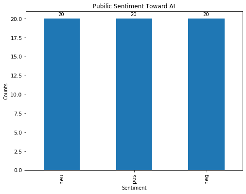

```python
# Collector's Sentiment as Public Sentiment toward AI
tweets['Sentiment']=tweets.Sentiment.map({-1:'neg', 0:'neu', 1:'pos'}) # mask with the strings

tweets.Sentiment.value_counts().plot(kind='bar', figsize=(8,6), fontsize=11,);
plt.title('Pubilic Sentiment Toward AI', size=12)
plt.xlabel('Sentiment')
plt.ylabel('Counts')
# add annotation on each bar
for i in range(3):
    plt.text(x = i - 0.05 , y = tweets.Sentiment.value_counts().values[i] + 0.4,
             s = tweets.Sentiment.value_counts().values[i])
plt.show()
```

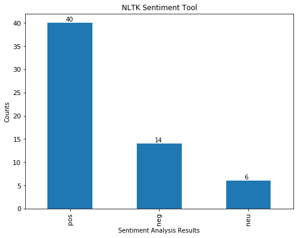

```python
# NLTK sentiment
tweets.NLTK_sentiment.value_counts().plot(kind='bar', figsize=(8,6), fontsize=11);
plt.title('NLTK Sentiment Tool', size=12)
plt.xlabel('Sentiment Analysis Results')
plt.ylabel('Counts')
# add annotation on each bar
for i in range(3):
    plt.text(x = i - 0.05 , y = tweets.NLTK_sentiment.value_counts().values[i] + 0.4,
             s = tweets.NLTK_sentiment.value_counts().values[i])
plt.show()
```

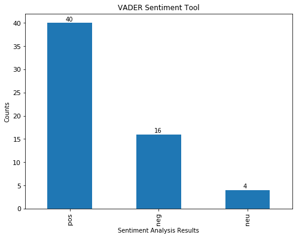

```python
# VADER sentiment
tweets.VADER_sentiment.value_counts().plot(kind='bar', figsize=(8,6), fontsize=11);
plt.title('VADER Sentiment Tool', size=12)
plt.xlabel('Sentiment Analysis Results')
plt.ylabel('Counts')
# add annotation on each bar
for i in range(3):
    plt.text(x = i - 0.05 , y = tweets.VADER_sentiment.value_counts().values[i] + 0.4,
             s = tweets.VADER_sentiment.value_counts().values[i])
plt.show()
```

### WordCloud

#### # Preparation

```python
from matplotlib.pyplot import imshow
import numpy as np
from skimage import io, color

cloud_mask_color = io.imread('tweet_mask.png')
cloud_mask_grey = color.rgb2grey(cloud_mask_color)
cloud_mask_grey.shape
```

```
(202, 249)
```

```python
def transform_mask(val, array_value=1):
    if val.all() == array_value:
        return 255 # setting the color to white
    else:
        return val
```

```python
# Transform your mask into a new array with the same dimension to work with the function:
transformed_cloud_mask = np.ndarray((cloud_mask_grey.shape[0],cloud_mask_grey.shape[1]), np.int32)
transformed_cloud_mask.shape
```

```
(202, 249)
```

```python
for i in range(len(cloud_mask_grey)):
    transformed_cloud_mask[i] = list(map(transform_mask, cloud_mask_grey[i]))
```

[figure not shown]

```python
imshow(transformed_cloud_mask);
```

#### # word clouds

```python
NLTK_neg = tweets[tweets.NLTK_sentiment=='neg']
NLTK_neu = tweets[tweets.NLTK_sentiment=='neu']
NLTK_pos = tweets[tweets.NLTK_sentiment=='pos']
VADER_neg = tweets[tweets.VADER_sentiment=='neg']
VADER_neu = tweets[tweets.VADER_sentiment=='neu']
VADER_pos = tweets[tweets.VADER_sentiment=='pos']
Public_neg = tweets[tweets.Sentiment=='neg']
Public_neu = tweets[tweets.Sentiment=='neu']
Public_pos = tweets[tweets.Sentiment=='pos']
```

```python
def my_wordcloud(df, title, stopword=[]):
    """
    Expect: @param-df:a pandas dataframe with a column, Tweets
            @param-title: wordcloud title
            @param-stopword: a list of stopword
    Modifies: show a word cloud and save it as png
    Return: no value return
    """
    from matplotlib.pyplot import imshow
    from wordcloud import WordCloud, STOPWORDS, ImageColorGenerator
    import matplotlib.pyplot as plt
    %matplotlib inline

    # Create stopword list:
    stopwords = set(STOPWORDS)
    stopwords.update(['robot', 'ai', 'artificial', 'intelligence','artificial intelligence',
                      'artificialintelligence', 'artificialIntelligence','ArtificialIntelligence'
                     ] + stopword)
    #convert list to string and generate
    unique_string=(" ").join(df.Tweets)
    text=unique_string.lower().strip()

    # use parameters to adjust your word cloud, such as
    # lower max_font_size, change the maximum number of word and lighten the background:
    wordcloud = WordCloud(font_path = 'arial', max_font_size=120, max_words=100, mask=transformed_cloud_mask,
                      stopwords=stopwords, background_color="white",
                      contour_width=2, contour_color='white').generate(text)
    plt.figure()
    plt.imshow(wordcloud, interpolation="bilinear")
    plt.axis("off")
    plt.title(title)
    plt.show()
    wordcloud.to_file(title+".png")
```

```python
def words_table(df, title, stopword=[]):
    """
    Expect: @param-df:a pandas dataframe with a column, Tweets
            @param-title: a string of table title
    Modifies: convert sparse matrix to summary table of taken counts; a 'words_tb' dataframe will be created
    Return: a filtered pandas dataframe
    """

    import pandas as pd
    from wordcloud import STOPWORDS
    from sklearn.feature_extraction.text import CountVectorizer
    vect = CountVectorizer()
    # learn the 'vocabulary' of the training data (occurs in-place)
    vect.fit(df.Tweets)
    # transform training data into a 'document-term matrix'
    tweets_dtm = vect.transform(df.Tweets)
    tweets_dtm
    # convert sparse matrix to a dense matrix
    dtm_array = tweets_dtm.toarray()
    # store the vocabulary of X_train
    tokens = vect.get_feature_names()
    # summarize the counts
    series = pd.DataFrame(dtm_array, columns=tokens).sum()
    words_tb = pd.DataFrame(series, columns=['Counts'], index=tokens).sort_values(['Counts'],ascending=False)
    print('{}:'.format(title))

    # Create stopword list:
    stopwords = set(STOPWORDS)
    stopwords.update(['robot', 'ai', 'artificial', 'intelligence','artificial intelligence',
                      'artificialintelligence', 'artificialIntelligence','ArtificialIntelligence'
                     ] + stopword)
    my_list = [w for w in stopwords]

    # filter the stop words
    Filter_df  = words_tb[~words_tb.index.isin(my_list)]
    return Filter_df
```

[figure not shown]

```python
my_wordcloud(NLTK_neg, title = 'NLTK_neg')
```

```python
words_table(NLTK_neg, 'NLTK_neg').head(10)
```

```
NLTK_neg:
```

|  | Counts |
| --- | --- |
| will | 6 |
| need | 3 |
| us | 3 |
| now | 3 |
| countries | 3 |
| going | 3 |
| hands | 2 |
| teams | 2 |
| current | 2 |
| fucked | 2 |

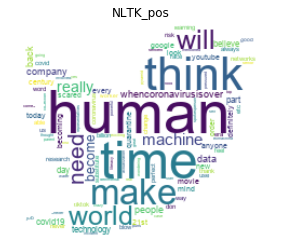

```python
my_wordcloud(NLTK_pos, title = 'NLTK_pos')
```

```python
words_table(NLTK_pos, 'NLTK_pos').head(10)
```

```
NLTK_pos:
```

|  | Counts |
| --- | --- |
| human | 7 |
| think | 6 |
| world | 6 |
| will | 6 |
| time | 5 |
| make | 5 |
| really | 4 |
| machine | 4 |
| people | 3 |
| need | 3 |

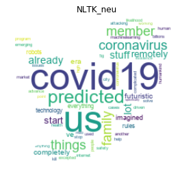

```python
my_wordcloud(NLTK_neu, title = 'NLTK_neu')
```

```python
words_table(NLTK_neu, 'NLTK_neu').head(10)
```

```
NLTK_neu:
```

|  | Counts |
| --- | --- |
| coronavirus | 2 |
| member | 2 |
| things | 2 |
| predicted | 2 |
| covid19 | 2 |
| us | 2 |
| family | 2 |
| program | 1 |
| remotely | 1 |
| robots | 1 |

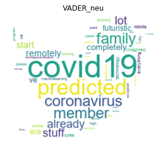

```python
my_wordcloud(VADER_neu, title = 'VADER_neu')
```

```python
words_table(VADER_neu, 'VADER_neu').head(10)
```

```
VADER_neu:
```

|  | Counts |
| --- | --- |
| member | 2 |
| predicted | 2 |
| covid19 | 2 |
| family | 2 |
| coronavirus | 2 |
| point | 1 |
| working | 1 |
| problems | 1 |
| program | 1 |
| remotely | 1 |

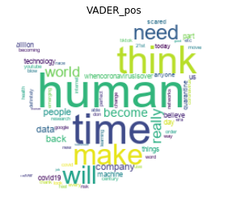

```python
my_wordcloud(VADER_pos, title = 'VADER_pos')
```

```python
words_table(VADER_pos, 'VADER_pos').head(10)
```

```
VADER_pos:
```

|  | Counts |
| --- | --- |
| human | 7 |
| will | 6 |
| think | 6 |
| make | 5 |
| time | 5 |
| really | 4 |
| world | 4 |
| things | 3 |
| day | 3 |
| data | 3 |

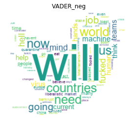

```python
my_wordcloud(VADER_neg, title = 'VADER_neg')
```

```python
words_table(VADER_neg, 'VADER_neg').head(10)
```

```
VADER_neg:
```

|  | Counts |
| --- | --- |
| will | 6 |
| countries | 3 |
| going | 3 |
| us | 3 |
| now | 3 |
| need | 3 |
| world | 3 |
| teams | 2 |
| hands | 2 |
| jobs | 2 |

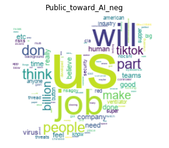

```python
my_wordcloud(Public_neg, title = 'Public_toward_AI_neg')
```

```python
words_table(Public_neg, 'Public_toward_AI_neg').head(10)
```

```
Public_toward_AI_neg:
```

|  | Counts |
| --- | --- |
| will | 4 |
| us | 4 |
| people | 3 |
| don | 3 |
| part | 3 |
| think | 3 |
| teams | 2 |
| company | 2 |
| virus | 2 |
| feel | 2 |

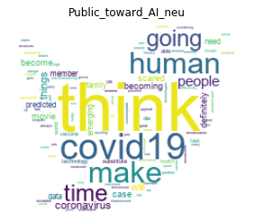

```python
my_wordcloud(Public_neu, title = 'Public_toward_AI_neu')
```

```python
words_table(Public_neu, 'Public_toward_AI_neu').head(10)
```

```
Public_toward_AI_neu:
```

|  | Counts |
| --- | --- |
| think | 4 |
| covid19 | 4 |
| make | 3 |
| people | 3 |
| things | 3 |
| coronavirus | 3 |
| going | 3 |
| will | 3 |
| time | 3 |
| human | 3 |

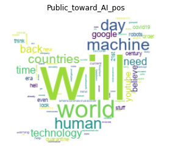

```python
my_wordcloud(Public_pos, title = 'Public_toward_AI_pos')
```

```python
words_table(Public_pos, 'Public_toward_AI_pos' ).head(10)
```

```
Public_toward_AI_pos:
```

|  | Counts |
| --- | --- |
| will | 5 |
| world | 5 |
| machine | 4 |
| human | 3 |
| technology | 3 |
| day | 3 |
| countries | 3 |
| need | 3 |
| back | 3 |
| covid19 | 2 |

```python
tweets
```

| Item | Sentiment | Tweets | NLTK_score | NLTK_sentiment | VADER_score | VADER_sentiment | match |
| --- | --- | --- | --- | --- | --- | --- | --- |
| 1 | neu | in case anyone was wondering how quarantine is going, here’s a real thought i had today: “i’m not scared of artificial intelligence; i’m scared of my puns becoming sentient” | 0.7853 | pos | 0.3830 | pos | 1.0 |
| 2 | neu | #ExMachina this movie blows my mind artificial intelligence can be exciting but at the same time detrimental when it comes to how powerful they can become. This movie definitely makes you think about … | 0.8074 | pos | 0.8074 | pos | 1.0 |
| 3 | pos | "representatives from Youtube mentioned that artificial Intelligence was involved in the incident and that they have pressured senior staff. A spokesperson from Google, Youtube’s parent company, | 0.2960 | pos | 0.2960 | pos | 1.0 |
| 4 | pos | Don't be fooled to believe quarantine helps. Countries will go bankrupt and then China will eat Europe like a toast. All fucked countries will be ruled by market liberalistic totalitarianism and artif… | -0.5132 | neg | -0.5132 | neg | 1.0 |
| 5 | pos | Since were already doing a lot of stuff remotely, what if #COVID19 is the start of the completely futuristic era we’ve all imagined of where technology rules and artificial intelligence/robots do ever… | 0.0000 | neu | 0.0000 | neu | 1.0 |
| 6 | neu | #ArtificialIntelligence #MachineLearning AI just predicted that the more people you have in a city the more Coronavirus cases are excepted! The AI program also predicted that when a family member has … | 0.0000 | neu | 0.0000 | neu | 1.0 |
| 7 | neu | "Think of Artificial Intelligence as the top of a pyramid of needs. Yes, self-actualization (AI) is great, but you first need food, water, and shelter (data literacy, collection, and infrastructure)." | 0.7050 | pos | 0.7050 | pos | 1.0 |
| 8 | pos | If AI becomes smarter than humans in the 21st century (which is fairly likely), than I think, when we look back (if we get to look back), we'll summarize the 21st century with just two words: 'artific… | 0.4588 | pos | 0.7269 | pos | 1.0 |
| 9 | pos | Autocorrect just changed "Batelle" to "Butt hell" in a group chat and I hereby decree that full artificial intelligence has arrived. | -0.3612 | neg | -0.3612 | neg | 1.0 |
| 10 | neg | Our supper American artificial intelligence AI industry can’t make a super ventilator? Com - on. | 0.7906 | pos | 0.7906 | pos | 1.0 |
| 11 | neu | "By far, the greatest danger of Artificial Intelligence is that people conclude too early that they understand it." | 0.5994 | pos | 0.5994 | pos | 1.0 |
| 12 | pos | There would be a New World Order and the implementation of Artificial Intelligence (AI) #WhenCoronaVirusIsOver | 0.4767 | pos | 0.4767 | pos | 1.0 |
| 13 | pos | #WhenCoronaVirusIsOver , I will inspire youths into research of artificial intelligence concepts such as neural networks, machine learning and data science | 0.7783 | pos | 0.7783 | pos | 1.0 |
| 14 | neu | If the advances in emerging technology were applied to disease outbreak, would we have been able to contain the COVID-19 effectively? Participate in Risk Group Poll and join the discussion. #pandemicp… | 0.4588 | pos | 0.4588 | pos | 1.0 |
| 15 | pos | Life is eternal in HELL, Mind Controlling itself or Artificial Intelligence the Machine that always wins the Game through Artificial means in an artificial world. The replications have no chance to be… | 0.0688 | pos | -0.0703 | neg | 0.0 |
| 16 | neg | Anyone know where that big red artificial intelligence off button is, @NSAGov @CIA @nbcsnl | 0.4767 | pos | 0.4767 | pos | 1.0 |
| 17 | neg | THE SECURITY THREATS/RISKS OF TIKTOK - A THREAD For background, TikTok is an app developed by ByteDance, a multi-billion ($ 75 billion) Chinese company that describes itself as an artificial intellige… | 0.7378 | pos | 0.7378 | pos | 1.0 |
| 18 | neg | We got 3rd place in the twitch rivals event AND THE 2 TEAMS ABOVE US ARE CHEATING FUCKING CONTROLLER TEAMS. I LOST TO ARTIFICIAL INTELLIGENCE | -0.6658 | neg | -0.5473 | neg | 1.0 |
| 19 | neu | I always say thank you to my Alexa because when the world gets taken over by artificial intelligence I think she’s gonna spare me bc I was kind. It’s a full proof plan. | 0.8402 | pos | 0.8402 | pos | 1.0 |
| 20 | neg | This corona virus should blow over just in time for artificial intelligence to gain consciousness and murder us all. #WhenCoronaVirusIsOver | 0.2023 | pos | 0.2023 | pos | 1.0 |
| 21 | pos | We need more than Artificial Intelligence these days , we need Artificial Craziness to cope with the current crisis & our current politicians ! | -0.5615 | neg | -0.5615 | neg | 1.0 |
| 22 | neu | We should not compete with artificial intelligence, but focus on developing unique human intelligence | 0.7351 | pos | 0.7351 | pos | 1.0 |
| 23 | neu | 5G is about the internet of things and artificial intelligence... and billions $ in an emerging market driven by those things. It's not about us or our health/safety. #nwo | 0.0000 | neu | 0.4767 | pos | 0.0 |
| 24 | pos | I'll believe artificial intelligence can replace human workers the day a robot writes an insufferable op-ed on how Covid confirms all its preexisting beliefs and policy prescriptions. | 0.4767 | pos | 0.4767 | pos | 1.0 |
| 25 | pos | a bigger fuckup if all this quarantine is to test whether they can implement artificial intelligence on a larger scale to make way for the new world order. | 0.4767 | pos | 0.4767 | pos | 1.0 |
| 26 | pos | Artificial intelligence will be happy everyone's lost they're jobs. | 0.6705 | pos | 0.6705 | pos | 1.0 |
| 27 | pos | Artificial intelligence is everywhere. From social networks, to uber from Siri to online banking the word has become synonymous with our day to day lives in a really short period of time. Artificial i… | 0.8519 | pos | 0.8519 | pos | 1.0 |
| 28 | pos | Artificial Intelligence is used to advance and solve most complicated issues for and against humankind. So, can artificial intelligence help stop and kill the conronavirus attacking human existence? | 0.0164 | neu | -0.0516 | neg | 0.0 |
| 29 | neg | I pray we never combine the human brain and artificial intelligence… | 0.3182 | pos | 0.3182 | pos | 1.0 |
| 30 | pos | Chinese usage of machine learning &artificial intelligence is mind boggling.Tool in the hands of devilish country is danger for world especially for neighbor's.Think tank shd be formed in armies how t… | -0.1280 | neg | -0.1280 | neg | 1.0 |
| 31 | pos | We are in the era of Artificial Intelligence. Human race on technology and innovation has bring a rapid change by using AI. But even having such a smart technology, today it seems that we are too back… | 0.8126 | pos | 0.7506 | pos | 1.0 |
| 32 | neu | This is a perfect time for artificial intelligence to take over. Be aware. | 0.7783 | pos | 0.7783 | pos | 1.0 |
| 33 | neu | Artificial intelligence has really pulled a fast one on us #COVID19 | 0.4767 | pos | 0.4767 | pos | 1.0 |
| 34 | neu | Do you fear #ArtificialIntelligence ? If so, why? | -0.5514 | neg | -0.5514 | neg | 1.0 |
| 35 | neu | In the world of Artificial Intelligence we are not able to make VACCINE @WHO #COVID19 | 0.4767 | pos | 0.4767 | pos | 1.0 |
| 36 | pos | What’s the point of working on anything other than #ArtificialIntelligence more specifically #ArtificialGeneralIntelligence | 0.0000 | neu | 0.0000 | neu | 1.0 |
| 37 | neu | If #ArtificialIntelligence is so fast at solving problems, youd think scientists could plug in the genome of #covid19 along with other viruses and their known cures, and AI could figure out a vaccine. | -0.0094 | neu | -0.0094 | neu | 1.0 |
| 38 | pos | Artificial intelligence doesn’t sound so bad now delivering our stuff and being the cashiers | -0.3381 | neg | -0.3381 | neg | 1.0 |
| 39 | neu | As long as there be ability to use data artificial intelligence priories is to determine all the circumference of pie @ThelIluminatii @Pontifex @POTUS | 0.6597 | pos | 0.6597 | pos | 1.0 |
| 40 | neu | Can you imagine the psychological damage corona virus is doing? It's going to be difficult to interact with people when things die down. We are going to become dependent on technology and artificial i… | -0.7351 | neg | -0.7351 | neg | 1.0 |
| 41 | neg | To my people with money and this economy slowing you paper. Invest in stocks that involve ARTIFICIAL INTELLIGENCE such as Tesla and many more. You think no jobs rn suck. Wait till a robot takes your j… | -0.1358 | neg | -0.1358 | neg | 1.0 |
| 42 | neg | Doesn’t it feel like this is the end of an era? I feel like this decade maybe the dawn of at least 30-40 percent of things being done through artificial intelligence | 0.7964 | pos | 0.7964 | pos | 1.0 |
| 43 | neg | I don’t like the dark, I’m afraid of the ocean and space, but oh my GOD do I hate artificial intelligence. That shit is TERRIFYING. | -0.8573 | neg | -0.8573 | neg | 1.0 |
| 44 | neg | AI isn’t perfect. Don’t believe me, check your qutocorreft #AI #ArtificialIntelligence | 0.5719 | pos | 0.5719 | pos | 1.0 |
| 45 | neg | Inspite of achieving quantum supremacy, Advanced Artificial Intelligence, Cloning, Gene Editing etc...etc.. Mother Nature has a funny way of showing the Human Race who’s really in charge! #WorldWarC #… | 0.8172 | pos | 0.8172 | pos | 1.0 |
| 46 | pos | Thanks to #Google, my translations require less time. #ArtificialIntelligence | 0.4404 | pos | 0.4404 | pos | 1.0 |
| 47 | pos | WE NEED AUTOMATION NOW MORE THAN EVER!! ROBOTS & A.I. CANT GET COVID-19 ;) #ArtificialIntelligence #COVID19 #coronavirus #AGI | -0.3071 | neg | -0.3071 | neg | 1.0 |
| 48 | neu | Machine Learning and Artificial Intelligence can never substitute the profession of a Doctor .Man health worker👩🏻‍⚕️ They can be a helping hand but can’t substitute them completely . | 0.5789 | pos | 0.5789 | pos | 1.0 |
| 49 | neg | No I think you all playing your part really well.And Q is probably an artificial intelligence psyop designed psychologicaly to calm the people so you give them a fake hope, someone to believe in While… | 0.5859 | pos | 0.5859 | pos | 1.0 |
| 50 | neg | I think you're overestimating the power of artificial intelligence. | 0.4767 | pos | 0.4767 | pos | 1.0 |
| 51 | neg | Artificial intelligence is no match for natural stupidity. | 0.1280 | pos | 0.1280 | pos | 1.0 |
| 52 | neg | Seeing what this virus has done to us, and the domino effect it has had on everything makes me realize we will be completely fucked if artificial intelligence is to ever get out of hands. | -0.3804 | neg | -0.3804 | neg | 1.0 |
| 53 | neg | Artificial intelligence is a synonym for a Republican. | 0.4767 | pos | 0.4767 | pos | 1.0 |
| 54 | neg | Artificial intelligence can not imagine the very *idea* of turning Rhapsody in Blue into a rap song | 0.4767 | pos | 0.4767 | pos | 1.0 |
| 55 | neu | Forget artificial intelligence and nuclear war, Professor Stephen Hawking has sensationally warned it will be humans’ stupidity and greed which will usher in the end of time. | -0.8555 | neg | -0.8555 | neg | 1.0 |
| 56 | neg | So Twitter uses Artificial Intelligence to monitor accounts. They are highly automated. They are very good at the artificial part...they are not so good at the intelligence part. Their brainiacs have … | 0.9449 | pos | 0.8737 | pos | 1.0 |
| 57 | neg | Do you remember when they scared us with stories of Artificial Intelligence taking our jobs? Now all the AI companies are going bust and I’m cleaning my ass in the shower. | -0.5106 | neg | -0.5106 | neg | 1.0 |
| 58 | neu | "Employment" and direct human transactions are becoming increasingly unnecessary for most industries. Everything will be manufactured, prepared, distributed and sold by artificial intelligence. So mal… | 0.4728 | pos | 0.4728 | pos | 1.0 |
| 59 | neg | Why do we keep electing and nominating 80 year olds to fix our problems? I don’t need the president to call me in the middle of the night to reset the clock on their VCR, I need them to help solve the… | 0.3818 | pos | 0.3818 | pos | 1.0 |
| 60 | neu | Lets stop hyping ‘Artificial Intelligence’. Artificial Intelligence can do nothing unless there’s human intention and intelligence behind driving Artificial Intelligence to make the right impact or ma… | 0.8934 | pos | 0.8934 | pos | 1.0 |